# Final Project - Will This Car Sell?

Group #1: Holland Robinson, Vu Nguyen, Kathryn Mioduszewski, Pranav Patil, Sreechandana Anumolu, Yash Ghate

4/14/2023

# Introduction

The data set we are using details used car data. The Y variable indicates whether or not a car is sold. The X variables include attributes such as car type, mileage, make, model, and other attributes. With this data, we are building an algorithm to predict the attributes that influence the sale of a car. This is relevant to used car dealerships when choosing to accept a car from a seller to subsequently sell to another buyer.

# Business Questions

The business questions we’re answering are: 1. Which cars will sell on my used car lot? 2. Can I predict which types of cars I should be purchasing to re-sell?

# Preliminary Exploration and Cleaning of Data

```r
car <- read.csv("Car_data (1).csv")

car$Sales_ID <- NULL
car$age <- max(car$year) - car$year
car$name <- as.factor(car$name)
car$State <- as.factor(car$State)
car$Region <- as.factor(car$Region)
car$seller_type <- as.factor(car$seller_type)
car$transmission <- as.factor(car$transmission)
car$fuel <- as.factor(car$fuel)
car$owner <- as.factor(car$owner)
car$sold <- as.factor(car$sold)
car$name <- ifelse(car$name == "Opel" | car$name == "Ashok" | car$name == "MG" | car$name == "Daewoo" | car$name == "Kia" | car$name == "Ambassador" | car$name == "Isuzu" | car$name == "Land" | car$name == "Force","Other", car$name)

car$City <- ifelse(car$City == "New York City" | car$City == "Los Angeles" | car$City == "Seattle" | car$City == "Chicago" | car$City == "Boston" | car$City == "Washington" | car$City == "Philadelphia" | car$City == "Charlotte" | car$City == "Miami" | car$City == "Detroit"  , car$City, "Other")

carv1 <- as.data.frame(model.matrix(~.-1,car))

str(car)
```

```
## 'data.frame':    7906 obs. of  19 variables:
##  $ name             : chr  "20" "27" "11" "12" ...
##  $ year             : int  2014 2014 2006 2010 2007 2017 2007 2001 2011 2013 ...
##  $ selling_price    : num  5488 4512 1927 2744 1585 ...
##  $ km_driven        : int  145500 120000 140000 127000 120000 45000 175000 5000 90000 169000 ...
##  $ Region           : Factor w/ 4 levels "Central","East",..: 2 2 1 1 2 2 4 4 4 1 ...
##  $ State.or.Province: chr  "District of Columbia" "New York" "Illinois" "Illinois" ...
##  $ City             : chr  "Washington" "New York City" "Chicago" "Chicago" ...
##  $ fuel             : Factor w/ 4 levels "CNG","Diesel",..: 2 2 4 2 4 4 3 4 2 2 ...
##  $ seller_type      : Factor w/ 3 levels "Dealer","Individual",..: 2 2 2 2 2 2 2 2 2 2 ...
##  $ transmission     : Factor w/ 2 levels "Automatic","Manual": 2 2 2 2 2 2 2 2 2 2 ...
##  $ owner            : Factor w/ 5 levels "First_Owner",..: 1 3 5 1 1 1 1 3 1 1 ...
##  $ mileage          : num  23.4 21.1 17.7 23 16.1 ...
##  $ engine           : int  1248 1498 1497 1396 1298 1197 1061 796 1364 1399 ...
##  $ max_power        : num  74 103.5 78 90 88.2 ...
##  $ Torque           : num  190 250 124 220 113 ...
##  $ seats            : int  5 5 5 5 5 5 5 4 5 5 ...
##  $ sold             : Factor w/ 2 levels "N","Y": 2 2 2 2 2 2 2 2 2 2 ...
##  $ age              : int  6 6 14 10 13 3 13 19 9 7 ...
##  $ State            : Factor w/ 49 levels "Alabama","Arizona",..: 8 31 12 12 31 31 4 4 4 42 ...
```

```r
summary(carv1)
```

```
##      name10            name11            name12          name14
##  Min.   :0.00000   Min.   :0.00000   Min.   :0.000   Min.   :0.000000
##  1st Qu.:0.00000   1st Qu.:0.00000   1st Qu.:0.000   1st Qu.:0.000000
##  Median :0.00000   Median :0.00000   Median :0.000   Median :0.000000
##  Mean   :0.04908   Mean   :0.05894   Mean   :0.172   Mean   :0.008981
##  3rd Qu.:0.00000   3rd Qu.:0.00000   3rd Qu.:0.000   3rd Qu.:0.000000
##  Max.   :1.00000   Max.   :1.00000   Max.   :1.000   Max.   :1.000000
##      name15             name18           name19            name20
##  Min.   :0.000000   Min.   :0.0000   Min.   :0.00000   Min.   :0.0000
##  1st Qu.:0.000000   1st Qu.:0.0000   1st Qu.:0.00000   1st Qu.:0.0000
##  Median :0.000000   Median :0.0000   Median :0.00000   Median :0.0000
##  Mean   :0.003921   Mean   :0.0043   Mean   :0.09588   Mean   :0.2994
##  3rd Qu.:0.000000   3rd Qu.:0.0000   3rd Qu.:0.00000   3rd Qu.:1.0000
##  Max.   :1.000000   Max.   :1.0000   Max.   :1.00000   Max.   :1.0000
##      name21            name23             name24            name26
##  Min.   :0.00000   Min.   :0.000000   Min.   :0.00000   Min.   :0.00000
##  1st Qu.:0.00000   1st Qu.:0.000000   1st Qu.:0.00000   1st Qu.:0.00000
##  Median :0.00000   Median :0.000000   Median :0.00000   Median :0.00000
##  Mean   :0.00683   Mean   :0.001771   Mean   :0.01025   Mean   :0.02884
##  3rd Qu.:0.00000   3rd Qu.:0.000000   3rd Qu.:0.00000   3rd Qu.:0.00000
##  Max.   :1.00000   Max.   :1.000000   Max.   :1.00000   Max.   :1.00000
##      name27            name28            name29            name3
##  Min.   :0.00000   Min.   :0.00000   Min.   :0.00000   Min.   :0.000000
##  1st Qu.:0.00000   1st Qu.:0.00000   1st Qu.:0.00000   1st Qu.:0.000000
##  Median :0.00000   Median :0.00000   Median :0.00000   Median :0.000000
##  Mean   :0.01315   Mean   :0.09094   Mean   :0.05717   Mean   :0.005059
##  3rd Qu.:0.00000   3rd Qu.:0.00000   3rd Qu.:0.00000   3rd Qu.:0.000000
##  Max.   :1.00000   Max.   :1.00000   Max.   :1.00000   Max.   :1.000000
##      name30           name31             name4             name5
##  Min.   :0.0000   Min.   :0.000000   Min.   :0.00000   Min.   :0.00000
##  1st Qu.:0.0000   1st Qu.:0.000000   1st Qu.:0.00000   1st Qu.:0.00000
##  Median :0.0000   Median :0.000000   Median :0.00000   Median :0.00000
##  Mean   :0.0234   Mean   :0.008475   Mean   :0.01493   Mean   :0.02909
##  3rd Qu.:0.0000   3rd Qu.:0.000000   3rd Qu.:0.00000   3rd Qu.:0.00000
##  Max.   :1.0000   Max.   :1.000000   Max.   :1.00000   Max.   :1.00000
##      name7              name8            nameOther             year
##  Min.   :0.000000   Min.   :0.000000   Min.   :0.000000   Min.   :1994
##  1st Qu.:0.000000   1st Qu.:0.000000   1st Qu.:0.000000   1st Qu.:2012
##  Median :0.000000   Median :0.000000   Median :0.000000   Median :2015
##  Mean   :0.008222   Mean   :0.005186   Mean   :0.004174   Mean   :2014
```

[output cut: 274 more lines]

```
##  Max.   :1.00000     Max.   :1.000000   Max.   :1.00000   Max.   :1.00000
##    StateUtah        StateVermont      StateVirginia     StateWashington
##  Min.   :0.00000   Min.   :0.000000   Min.   :0.00000   Min.   :0.00000
##  1st Qu.:0.00000   1st Qu.:0.000000   1st Qu.:0.00000   1st Qu.:0.00000
##  Median :0.00000   Median :0.000000   Median :0.00000   Median :0.00000
##  Mean   :0.01682   Mean   :0.006324   Mean   :0.02112   Mean   :0.03731
##  3rd Qu.:0.00000   3rd Qu.:0.000000   3rd Qu.:0.00000   3rd Qu.:0.00000
##  Max.   :1.00000   Max.   :1.000000   Max.   :1.00000   Max.   :1.00000
##  StateWest Virginia StateWisconsin    StateWyoming
##  Min.   :0.000000   Min.   :0.0000   Min.   :0.000000
##  1st Qu.:0.000000   1st Qu.:0.0000   1st Qu.:0.000000
##  Median :0.000000   Median :0.0000   Median :0.000000
##  Mean   :0.004174   Mean   :0.0148   Mean   :0.001518
##  3rd Qu.:0.000000   3rd Qu.:0.0000   3rd Qu.:0.000000
##  Max.   :1.000000   Max.   :1.0000   Max.   :1.000000
```

## Normalize Data

```r
normalize <- function(x){
  return((x-min(x))/(max(x)-min(x)))
}

car_norm <- as.data.frame(lapply(carv1, normalize))

summary(car_norm)
```

```
##      name10            name11            name12          name14
##  Min.   :0.00000   Min.   :0.00000   Min.   :0.000   Min.   :0.000000
##  1st Qu.:0.00000   1st Qu.:0.00000   1st Qu.:0.000   1st Qu.:0.000000
##  Median :0.00000   Median :0.00000   Median :0.000   Median :0.000000
##  Mean   :0.04908   Mean   :0.05894   Mean   :0.172   Mean   :0.008981
##  3rd Qu.:0.00000   3rd Qu.:0.00000   3rd Qu.:0.000   3rd Qu.:0.000000
##  Max.   :1.00000   Max.   :1.00000   Max.   :1.000   Max.   :1.000000
##      name15             name18           name19            name20
##  Min.   :0.000000   Min.   :0.0000   Min.   :0.00000   Min.   :0.0000
##  1st Qu.:0.000000   1st Qu.:0.0000   1st Qu.:0.00000   1st Qu.:0.0000
##  Median :0.000000   Median :0.0000   Median :0.00000   Median :0.0000
##  Mean   :0.003921   Mean   :0.0043   Mean   :0.09588   Mean   :0.2994
##  3rd Qu.:0.000000   3rd Qu.:0.0000   3rd Qu.:0.00000   3rd Qu.:1.0000
##  Max.   :1.000000   Max.   :1.0000   Max.   :1.00000   Max.   :1.0000
##      name21            name23             name24            name26
##  Min.   :0.00000   Min.   :0.000000   Min.   :0.00000   Min.   :0.00000
##  1st Qu.:0.00000   1st Qu.:0.000000   1st Qu.:0.00000   1st Qu.:0.00000
##  Median :0.00000   Median :0.000000   Median :0.00000   Median :0.00000
##  Mean   :0.00683   Mean   :0.001771   Mean   :0.01025   Mean   :0.02884
##  3rd Qu.:0.00000   3rd Qu.:0.000000   3rd Qu.:0.00000   3rd Qu.:0.00000
##  Max.   :1.00000   Max.   :1.000000   Max.   :1.00000   Max.   :1.00000
##      name27            name28            name29            name3
##  Min.   :0.00000   Min.   :0.00000   Min.   :0.00000   Min.   :0.000000
##  1st Qu.:0.00000   1st Qu.:0.00000   1st Qu.:0.00000   1st Qu.:0.000000
##  Median :0.00000   Median :0.00000   Median :0.00000   Median :0.000000
##  Mean   :0.01315   Mean   :0.09094   Mean   :0.05717   Mean   :0.005059
##  3rd Qu.:0.00000   3rd Qu.:0.00000   3rd Qu.:0.00000   3rd Qu.:0.000000
##  Max.   :1.00000   Max.   :1.00000   Max.   :1.00000   Max.   :1.000000
##      name30           name31             name4             name5
##  Min.   :0.0000   Min.   :0.000000   Min.   :0.00000   Min.   :0.00000
##  1st Qu.:0.0000   1st Qu.:0.000000   1st Qu.:0.00000   1st Qu.:0.00000
##  Median :0.0000   Median :0.000000   Median :0.00000   Median :0.00000
##  Mean   :0.0234   Mean   :0.008475   Mean   :0.01493   Mean   :0.02909
##  3rd Qu.:0.0000   3rd Qu.:0.000000   3rd Qu.:0.00000   3rd Qu.:0.00000
##  Max.   :1.0000   Max.   :1.000000   Max.   :1.00000   Max.   :1.00000
##      name7              name8            nameOther             year
##  Min.   :0.000000   Min.   :0.000000   Min.   :0.000000   Min.   :0.0000
##  1st Qu.:0.000000   1st Qu.:0.000000   1st Qu.:0.000000   1st Qu.:0.6923
##  Median :0.000000   Median :0.000000   Median :0.000000   Median :0.8077
##  Mean   :0.008222   Mean   :0.005186   Mean   :0.004174   Mean   :0.7686
```

[output cut: 274 more lines]

```
##  Max.   :1.00000     Max.   :1.000000   Max.   :1.00000   Max.   :1.00000
##    StateUtah        StateVermont      StateVirginia     StateWashington
##  Min.   :0.00000   Min.   :0.000000   Min.   :0.00000   Min.   :0.00000
##  1st Qu.:0.00000   1st Qu.:0.000000   1st Qu.:0.00000   1st Qu.:0.00000
##  Median :0.00000   Median :0.000000   Median :0.00000   Median :0.00000
##  Mean   :0.01682   Mean   :0.006324   Mean   :0.02112   Mean   :0.03731
##  3rd Qu.:0.00000   3rd Qu.:0.000000   3rd Qu.:0.00000   3rd Qu.:0.00000
##  Max.   :1.00000   Max.   :1.000000   Max.   :1.00000   Max.   :1.00000
##  StateWest.Virginia StateWisconsin    StateWyoming
##  Min.   :0.000000   Min.   :0.0000   Min.   :0.000000
##  1st Qu.:0.000000   1st Qu.:0.0000   1st Qu.:0.000000
##  Median :0.000000   Median :0.0000   Median :0.000000
##  Mean   :0.004174   Mean   :0.0148   Mean   :0.001518
##  3rd Qu.:0.000000   3rd Qu.:0.0000   3rd Qu.:0.000000
##  Max.   :1.000000   Max.   :1.0000   Max.   :1.000000
```

## Split Data

```r
set.seed(12345)
test_rows <- sample(1:nrow(car_norm), 0.5*nrow(car_norm))
test_rows_dt <- sample(1:nrow(car),0.5*nrow(car))
car_test <- car_norm[test_rows, ]
car_train <- car_norm[-test_rows, ]

# Data Cleaning & creating test and train for KNN
carknn_test <- car_norm[test_rows,-match("soldY",names(car_norm))]
carknn_train <- car_norm[-test_rows,-match("soldY",names(car_norm))]
carknn_test_labels <- car_norm[test_rows,"soldY"]
carknn_train_labels <- car_norm[-test_rows,"soldY"]

# Data Cleaning and creating test and train for Decision Tree
cardt_train <- car[-test_rows_dt, ]
cardt_test <- car[test_rows_dt, ]
```

# Prediction Models

## Logistic Regression Model

```r
# Build Model
basemodel <- glm(soldY ~., data = car_train, family = "binomial")
summary(basemodel)
```

```
##
## Call:
## glm(formula = soldY ~ ., family = "binomial", data = car_train)
##
## Deviance Residuals:
##    Min      1Q  Median      3Q     Max
##  -8.49    0.00    0.00    0.00    8.49
##
## Coefficients: (54 not defined because of singularities)
##                                         Estimate Std. Error    z value Pr(>|z|)
## (Intercept)                            3.165e+15  2.966e+07  106677286   <2e-16
## name10                                 1.323e+15  1.850e+07   71488599   <2e-16
## name11                                 1.172e+15  1.841e+07   63636142   <2e-16
## name12                                 9.422e+14  1.804e+07   52236416   <2e-16
## name14                                 6.007e+14  2.238e+07   26844173   <2e-16
## name15                                 1.864e+15  2.404e+07   77527363   <2e-16
## name18                                -2.271e+14  2.778e+07   -8174804   <2e-16
## name19                                 1.167e+15  1.827e+07   63847730   <2e-16
## name20                                 9.784e+14  1.802e+07   54287289   <2e-16
## name21                                 3.370e+14  2.245e+07   15011931   <2e-16
## name23                                -1.961e+15  4.283e+07  -45798091   <2e-16
## name24                                 1.879e+15  2.074e+07   90596638   <2e-16
## name26                                 9.084e+14  1.906e+07   47665995   <2e-16
## name27                                 1.516e+14  2.011e+07    7540157   <2e-16
## name28                                 1.062e+15  1.818e+07   58434153   <2e-16
## name29                                 1.326e+15  1.831e+07   72396417   <2e-16
## name3                                  4.775e+14  2.334e+07   20457934   <2e-16
## name30                                 7.412e+14  1.913e+07   38742441   <2e-16
## name31                                 2.460e+14  2.195e+07   11207226   <2e-16
## name4                                  1.964e+14  2.112e+07    9301613   <2e-16
## name5                                  1.239e+15  1.887e+07   65665639   <2e-16
## name7                                 -4.094e+14  2.161e+07  -18946187   <2e-16
## name8                                 -1.604e+15  2.431e+07  -65954742   <2e-16
## nameOther                                     NA         NA         NA       NA
## year                                  -7.264e+14  1.142e+07  -63626262   <2e-16
## selling_price                          1.696e+15  3.480e+07   48725586   <2e-16
## km_driven                              8.992e+14  4.607e+07   19518772   <2e-16
## RegionEast                            -8.254e+14  1.701e+07  -48527189   <2e-16
## RegionSouth                           -2.117e+15  1.340e+07 -158006651   <2e-16
## RegionWest                            -3.377e+15  2.898e+07 -116537199   <2e-16
```

[output cut: 270 more lines]

```
## StateVirginia
## StateWashington
## StateWest.Virginia
## StateWisconsin
## StateWyoming
## ---
## Signif. codes:  0 '***' 0.001 '**' 0.01 '*' 0.05 '.' 0.1 ' ' 1
##
## (Dispersion parameter for binomial family taken to be 1)
##
##     Null deviance:  4467.1  on 3952  degrees of freedom
## Residual deviance: 50533.2  on 3855  degrees of freedom
## AIC: 50729
##
## Number of Fisher Scoring iterations: 25
```

```r
# Predict Model
library(caret)
carpred <- predict(basemodel, car_test, type = "response")
car_binary_pred <- ifelse(carpred >= 0.5, 1, 0)

#table(car_binary_pred)
a<-confusionMatrix(as.factor(car_binary_pred), as.factor(car_test$soldY))
kappa_Regression<- a$overall["Kappa"]
print(kappa_Regression)
```

```
##     Kappa
## 0.4571093
```

```r
print(a)
```

```
## Confusion Matrix and Statistics
##
##           Reference
## Prediction    0    1
##          0 2659  472
##          1  292  530
##
##                Accuracy : 0.8067
##                  95% CI : (0.7941, 0.8189)
##     No Information Rate : 0.7465
##     P-Value [Acc > NIR] : < 2.2e-16
##
##                   Kappa : 0.4571
##
##  Mcnemar's Test P-Value : 9.419e-11
##
##             Sensitivity : 0.9011
##             Specificity : 0.5289
##          Pos Pred Value : 0.8492
##          Neg Pred Value : 0.6448
##              Prevalence : 0.7465
##          Detection Rate : 0.6727
##    Detection Prevalence : 0.7921
##       Balanced Accuracy : 0.7150
##
##        'Positive' Class : 0
##
```

The matrix above shows that the logistic regression model predicted 530 cars will be sold successfully, and that we should avoid buying 2659 cars as they will not be sold. However, the prediction causes us to miss out on 472 cars, as they could have been sold, but they were not purchased. Furthermore, we take a loss on 292 cars, as we bought those cars and will not be able to sell them.

## KNN Model

```r
# Build Model
library(class)
knn_model <- knn(carknn_train,carknn_test,carknn_train_labels,k=40,prob= TRUE)

# Evaluate Model
library(caret)
b<-confusionMatrix(as.factor(knn_model), as.factor(carknn_test_labels),positive = "1")

kappa_KNN<-b$overall["Kappa"]
print(kappa_KNN)
```

```
##     Kappa
## 0.4193596
```

```r
print(b)
```

```
## Confusion Matrix and Statistics
##
##           Reference
## Prediction    0    1
##          0 2936  667
##          1   15  335
##
##                Accuracy : 0.8275
##                  95% CI : (0.8153, 0.8391)
##     No Information Rate : 0.7465
##     P-Value [Acc > NIR] : < 2.2e-16
##
##                   Kappa : 0.4194
##
##  Mcnemar's Test P-Value : < 2.2e-16
##
##             Sensitivity : 0.33433
##             Specificity : 0.99492
##          Pos Pred Value : 0.95714
##          Neg Pred Value : 0.81488
##              Prevalence : 0.25348
##          Detection Rate : 0.08475
##    Detection Prevalence : 0.08854
##       Balanced Accuracy : 0.66462
##
##        'Positive' Class : 1
##
```

The matrix above shows that the KNN Model predicted 335 cars will be sold successfully, and that we should avoid buying 2936 cars as they will not be sold. However, the prediction causes us to miss out on 667 cars, as they could have been sold, but they were not purchased. Furthermore, we take a loss on 15 cars, as we bought those cars and will not be able to sell them.

## ANN Model

```r
library(neuralnet)

# Build Model
model_ann1 <- neuralnet(soldY ~., data = car_train, hidden = 5,2)
plot(model_ann1)
saveRDS(model_ann1, file = 'model_ann1.rds')

# Predict Model
model_ann_1predict <- predict(model_ann1,car_test)
model_ann1bin <- ifelse(model_ann_1predict >= 0.25,1,0)

# Evaluate Model
library(caret)
c<-confusionMatrix(as.factor(model_ann1bin), as.factor(car_test$soldY), positive = "1")
kappa_ANN<- c$overall["Kappa"]
print(kappa_ANN)
```

```
##     Kappa
## 0.3684457
```

```r
print(c)
```

```
## Confusion Matrix and Statistics
##
##           Reference
## Prediction    0    1
##          0 2215  334
##          1  736  668
##
##                Accuracy : 0.7293
##                  95% CI : (0.7152, 0.7431)
##     No Information Rate : 0.7465
##     P-Value [Acc > NIR] : 0.9936
##
##                   Kappa : 0.3684
##
##  Mcnemar's Test P-Value : <2e-16
##
##             Sensitivity : 0.6667
##             Specificity : 0.7506
##          Pos Pred Value : 0.4758
##          Neg Pred Value : 0.8690
##              Prevalence : 0.2535
##          Detection Rate : 0.1690
##    Detection Prevalence : 0.3552
##       Balanced Accuracy : 0.7086
##
##        'Positive' Class : 1
##
```

The matrix above shows that the ANN Model predicted 668 cars will be sold successfully, and that we should avoid buying 2215 cars as they will not be sold. However, the prediction causes us to miss out on 334 cars, as they could have been sold, but they were not purchased. Furthermore, we take a loss on 736 cars, as we bought those cars and will not be able to sell them.

## Decision Tree

```r
library(C50)
```

[figure not shown]

```r
# Build Model
set.seed(12345)
cartree <- C5.0(as.factor(sold)~., data = cardt_train)
plot(cartree)
```

```r
summary(cartree)
```

```
##
## Call:
## C5.0.formula(formula = as.factor(sold) ~ ., data = cardt_train)
##
##
## C5.0 [Release 2.07 GPL Edition]      Mon Apr 17 22:29:16 2023
## -------------------------------
##
## Class specified by attribute `outcome'
##
## Read 3953 cases (19 attributes) from undefined.data
##
## Decision tree:
##
## City in {New York City,Los Angeles,Boston,Chicago,Seattle,Washington,Charlotte,
## :        Philadelphia,Miami,Detroit}: Y (445/16)
## City = Other: N (3508/553)
##
##
## Evaluation on training data (3953 cases):
##
##      Decision Tree
##    ----------------
##    Size      Errors
##
##       2  569(14.4%)   <<
##
##
##     (a)   (b)    <-classified as
##    ----  ----
##    2955    16    (a): class N
##     553   429    (b): class Y
##
##
##  Attribute usage:
##
##  100.00% City
##
##
## Time: 0.0 secs
```

```r
# Predict Model
cartreepred <- predict(cartree, cardt_test)
summary(cartreepred)
```

```
##    N    Y
## 3499  454
```

```r
# Evaluate Model
d<- confusionMatrix(as.factor(cartreepred),as.factor(cardt_test$sold), positive = "Y")

kappa_DecisionTree<- d$overall["Kappa"]
print(kappa_DecisionTree)
```

```
##    Kappa
## 0.507336
```

```r
print(d)
```

```
## Confusion Matrix and Statistics
##
##           Reference
## Prediction    N    Y
##          N 2912  587
##          Y   23  431
##
##                Accuracy : 0.8457
##                  95% CI : (0.834, 0.8568)
##     No Information Rate : 0.7425
##     P-Value [Acc > NIR] : < 2.2e-16
##
##                   Kappa : 0.5073
##
##  Mcnemar's Test P-Value : < 2.2e-16
##
##             Sensitivity : 0.4234
##             Specificity : 0.9922
##          Pos Pred Value : 0.9493
##          Neg Pred Value : 0.8322
##              Prevalence : 0.2575
##          Detection Rate : 0.1090
##    Detection Prevalence : 0.1148
##       Balanced Accuracy : 0.7078
##
##        'Positive' Class : Y
##
```

The matrix above shows that the Decision Tree predicted 431 cars will be sold successfully, and that we should avoid buying 2912 cars as they will not be sold. However, the prediction causes us to miss out on 587 cars, as they could have been sold, but they were not purchased. Furthermore, we take a loss on 23 cars, as we bought those cars and will not be able to sell them.

## Random Forest

```r
library(randomForest)
# Predict Model
carforest <- randomForest(as.factor(soldY) ~. , data = car_train)
summary(carforest)
```

```
##                 Length Class  Mode
## call               3   -none- call
## type               1   -none- character
## predicted       3953   factor numeric
## err.rate        1500   -none- numeric
## confusion          6   -none- numeric
## votes           7906   matrix numeric
## oob.times       3953   -none- numeric
## classes            2   -none- character
## importance       151   -none- numeric
## importanceSD       0   -none- NULL
## localImportance    0   -none- NULL
## proximity          0   -none- NULL
## ntree              1   -none- numeric
## mtry               1   -none- numeric
## forest            14   -none- list
## y               3953   factor numeric
## test               0   -none- NULL
## inbag              0   -none- NULL
## terms              3   terms  call
```

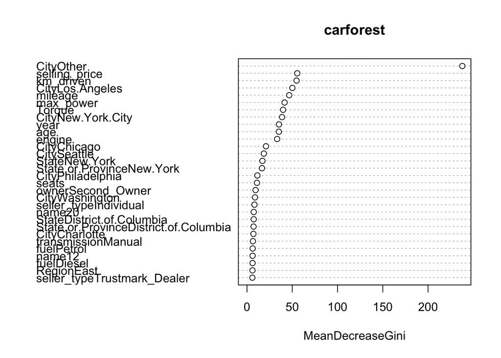

```r
randomForest::varImpPlot(carforest)
```

```r
# Evaluate and Predict
carrfpredict <- predict(carforest, car_test)
summary(carrfpredict)
```

```
##    0    1
## 3471  482
```

```r
e<- confusionMatrix(as.factor(carrfpredict), as.factor(car_test$soldY), positive = "1")
kappa_RandomForest<-e$overall["Kappa"]
print(kappa_RandomForest)
```

```
##     Kappa
## 0.5208313
```

```r
print(e)
```

```
## Confusion Matrix and Statistics
##
##           Reference
## Prediction    0    1
##          0 2914  557
##          1   37  445
##
##                Accuracy : 0.8497
##                  95% CI : (0.8382, 0.8607)
##     No Information Rate : 0.7465
##     P-Value [Acc > NIR] : < 2.2e-16
##
##                   Kappa : 0.5208
##
##  Mcnemar's Test P-Value : < 2.2e-16
##
##             Sensitivity : 0.4441
##             Specificity : 0.9875
##          Pos Pred Value : 0.9232
##          Neg Pred Value : 0.8395
##              Prevalence : 0.2535
##          Detection Rate : 0.1126
##    Detection Prevalence : 0.1219
##       Balanced Accuracy : 0.7158
##
##        'Positive' Class : 1
##
```

The matrix above shows that the Random Forest predicted 445 cars will be sold successfully, and that we should avoid buying 2914 cars as they will not be sold. However, the prediction causes us to miss out on 557 cars, as they could have been sold, but they were not purchased. Furthermore, we take a loss on 37 cars, as we bought those cars and will not be able to sell them.

# Stacked Model

```r
# Combine Models
stacked_car <- data.frame(log_pred = carpred, KNN = knn_model, ANN = model_ann_1predict, DT_pred = cartreepred, rf_pred = carrfpredict,y = car_test$soldY)

summary(stacked_car)
```

```
##     log_pred      KNN           ANN           DT_pred  rf_pred
##  Min.   :0.0000   0:3603   Min.   :-0.43810   N:3499   0:3471
##  1st Qu.:0.0000   1: 350   1st Qu.: 0.06036   Y: 454   1: 482
##  Median :0.0000            Median : 0.17844
##  Mean   :0.2079            Mean   : 0.25038
##  3rd Qu.:0.0000            3rd Qu.: 0.31410
##  Max.   :1.0000            Max.   : 1.48984
##        y
##  Min.   :0.0000
##  1st Qu.:0.0000
##  Median :0.0000
##  Mean   :0.2535
##  3rd Qu.:1.0000
##  Max.   :1.0000
```

```r
# Split Data
set.seed(1234)
test_set1 <- sample(1:nrow(stacked_car), 0.3*nrow(stacked_car))
cars_train_st <- stacked_car[-test_set1, ]
cars_test_st <- stacked_car[test_set1, ]
```

## Stacked Model Decision tree

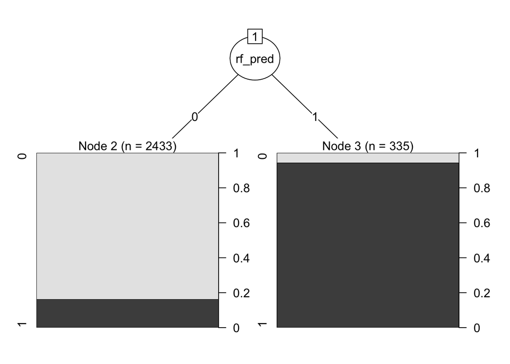

```r
library(C50)

stackedtree <- C5.0(as.factor(y) ~., data = cars_train_st)
plot(stackedtree)
```

```r
# Predict and Evaluate Model
library(caret)
stackedpredict <- predict(stackedtree,cars_test_st)
f<- confusionMatrix(as.factor(stackedpredict), as.factor(cars_test_st$y), positive = "1")

kappa_StackedModelDT<-f$overall["Kappa"]
print(kappa_StackedModelDT)
```

```
##   Kappa
## 0.51139
```

```r
print(f)
```

```
## Confusion Matrix and Statistics
##
##           Reference
## Prediction   0   1
##          0 878 160
##          1  18 129
##
##                Accuracy : 0.8498
##                  95% CI : (0.8282, 0.8697)
##     No Information Rate : 0.7561
##     P-Value [Acc > NIR] : 1.737e-15
##
##                   Kappa : 0.5114
##
##  Mcnemar's Test P-Value : < 2.2e-16
##
##             Sensitivity : 0.4464
##             Specificity : 0.9799
##          Pos Pred Value : 0.8776
##          Neg Pred Value : 0.8459
##              Prevalence : 0.2439
##          Detection Rate : 0.1089
##    Detection Prevalence : 0.1241
##       Balanced Accuracy : 0.7131
##
##        'Positive' Class : 1
##
```

The matrix above shows that the Stacked Model Decision Tree predicted 129 cars will be sold successfully, and that we should avoid buying 878 cars as they will not be sold. However, the prediction causes us to miss out on 160 cars, as they could have been sold, but they were not purchased. Furthermore, we take a loss on 18 cars, as we bought those cars and will not be able to sell them.

## Cost Matrix

```r
error_cost = matrix(c(0,1,4,0), nrow =2)
error_cost
```

```
##      [,1] [,2]
## [1,]    0    4
## [2,]    1    0
```

```r
errormodel <- C5.0(as.factor(y)~., data = cars_train_st,costs = error_cost)
prederror <- predict(errormodel, cars_test_st)
summary(prederror)
```

```
##   0   1
## 565 620
```

```r
g<-confusionMatrix(as.factor(prederror), as.factor(cars_test_st$y), positive = "1")
kappa_InitialCostMatrix<-g$overall["Kappa"]
print(kappa_InitialCostMatrix)
```

```
##     Kappa
## 0.2564952
```

```r
print(g)
```

```
## Confusion Matrix and Statistics
##
##           Reference
## Prediction   0   1
##          0 505  60
##          1 391 229
##
##                Accuracy : 0.6194
##                  95% CI : (0.5911, 0.6472)
##     No Information Rate : 0.7561
##     P-Value [Acc > NIR] : 1
##
##                   Kappa : 0.2565
##
##  Mcnemar's Test P-Value : <2e-16
##
##             Sensitivity : 0.7924
##             Specificity : 0.5636
##          Pos Pred Value : 0.3694
##          Neg Pred Value : 0.8938
##              Prevalence : 0.2439
##          Detection Rate : 0.1932
##    Detection Prevalence : 0.5232
##       Balanced Accuracy : 0.6780
##
##        'Positive' Class : 1
##
```

The generated matrix shows that the Cost Matrix predicted 229 cars will be sold successfully, and that we should avoid buying 505 cars as they will not be sold. However, the prediction causes us to miss out on 60 cars, as they could have been sold, but they were not purchased. Furthermore, we take a loss on 391 cars, as we bought those cars and will not be able to sell them.

## Improved Decsion Tree

```r
library(caret)
set.seed(12345)
ctrl <- trainControl(method = "cv", number = 10, selectionFunction = "oneSE")

#ctrl <- trainControl(selectionFunction = "oneSE")
grid <- expand.grid(.model="tree", .trials= c(1,5,10,15,20), .winnow="FALSE")

train_model_dt <- train(as.factor(soldY) ~., data = car_train, method="C5.0", metric="Kappa", trControl=ctrl, tuneGrid= grid)
predict_train_dt <- predict(train_model_dt, car_test)
h<-confusionMatrix(as.factor(predict_train_dt), as.factor(car_test$soldY), positive="1")

kappa_ImprovedDT<-h$overall["Kappa"]
print(kappa_ImprovedDT)
```

```
##     Kappa
## 0.5224897
```

```r
print(h)
```

```
## Confusion Matrix and Statistics
##
##           Reference
## Prediction    0    1
##          0 2928  564
##          1   23  438
##
##                Accuracy : 0.8515
##                  95% CI : (0.84, 0.8625)
##     No Information Rate : 0.7465
##     P-Value [Acc > NIR] : < 2.2e-16
##
##                   Kappa : 0.5225
##
##  Mcnemar's Test P-Value : < 2.2e-16
##
##             Sensitivity : 0.4371
##             Specificity : 0.9922
##          Pos Pred Value : 0.9501
##          Neg Pred Value : 0.8385
##              Prevalence : 0.2535
##          Detection Rate : 0.1108
##    Detection Prevalence : 0.1166
##       Balanced Accuracy : 0.7147
##
##        'Positive' Class : 1
##
```

The generated matrix shows that the Improved Decision Tree predicted 438 cars will be sold successfully, and that we should avoid buying 2928 cars as they will not be sold. However, the prediction causes us to miss out on 564 cars, as they could have been sold, but they were not purchased. Furthermore, we take a loss on 23 cars, as we bought those cars and will not be able to sell them.

# Tuning

## KNN Tuning

```r
library(caret)

# Define the tuning grid
grid_knn <- expand.grid(k = seq(5,60,5))

# Define the training control
ctrl_knn <- trainControl(method = "cv", number = 4, selectionFunction = "oneSE")

# Train KNN model
set.seed(12345)
train_model_knn <- train(as.factor(soldY)~ ., data = car_train, method = "knn", metric="Kappa", trControl = ctrl_knn, tuneGrid = grid_knn, preProcess=c("center","scale"))

#train_model_knn
summary(train_model_knn)
```

```
##             Length Class      Mode
## learn         2    -none-     list
## k             1    -none-     numeric
## theDots       0    -none-     list
## xNames      151    -none-     character
## problemType   1    -none-     character
## tuneValue     1    data.frame list
## obsLevels     2    -none-     character
## param         0    -none-     list
```

```r
# Make predictions on the test set
predict_train_knn <- predict(train_model_knn, car_test)

# Generate confusion matrix
i<- confusionMatrix(as.factor(predict_train_knn), as.factor(car_test$soldY), positive = "1")

Kappa_TunedKNN<-i$overall["Kappa"]
print(Kappa_TunedKNN)
```

```
##    Kappa
## 0.487864
```

```r
print(i)
```

```
## Confusion Matrix and Statistics
##
##           Reference
## Prediction    0    1
##          0 2923  595
##          1   28  407
##
##                Accuracy : 0.8424
##                  95% CI : (0.8307, 0.8536)
##     No Information Rate : 0.7465
##     P-Value [Acc > NIR] : < 2.2e-16
##
##                   Kappa : 0.4879
##
##  Mcnemar's Test P-Value : < 2.2e-16
##
##             Sensitivity : 0.4062
##             Specificity : 0.9905
##          Pos Pred Value : 0.9356
##          Neg Pred Value : 0.8309
##              Prevalence : 0.2535
##          Detection Rate : 0.1030
##    Detection Prevalence : 0.1100
##       Balanced Accuracy : 0.6983
##
##        'Positive' Class : 1
##
```

The generated matrix shows that the KNN Tuned Model predicted 407 cars will be sold successfully, and that we should avoid buying 2923 cars as they will not be sold. However, the prediction causes us to miss out on 595 cars, as they could have been sold, but they were not purchased. Furthermore, we take a loss on 28 cars, as we bought those cars and will not be able to sell them.

## Random Forest Tuning

```r
# Define the training control
ctrl_rf <- trainControl(method = "cv", number = 3, selectionFunction = "oneSE")

# Define the tuning grid
grid_rf <- expand.grid(.mtry = c(2, 4, 8))

set.seed(12345)
train_model_rf <- train(as.factor(soldY) ~ ., data = car_train, method = "rf", metric = "Kappa", trControl = ctrl_rf, tuneGrid = grid_rf)

train_model_rf
```

```
## Random Forest
##
## 3953 samples
##  151 predictor
##    2 classes: '0', '1'
##
## No pre-processing
## Resampling: Cross-Validated (3 fold)
## Summary of sample sizes: 2635, 2635, 2636
## Resampling results across tuning parameters:
##
##   mtry  Accuracy   Kappa
##   2     0.7801676  0.1816144
##   4     0.8413890  0.4740245
##   8     0.8502421  0.5152055
##
## Kappa was used to select the optimal model using  the one SE rule.
## The final value used for the model was mtry = 8.
```

```r
predict_train_rf <- predict(train_model_rf, car_test)

j<-confusionMatrix(as.factor(predict_train_rf), as.factor(car_test$soldY), positive = "1")

kappa_TunedRandomForest<-j$overall["Kappa"]
print(kappa_TunedRandomForest)
```

```
##     Kappa
## 0.5238761
```

```r
print(j)
```

```
## Confusion Matrix and Statistics
##
##           Reference
## Prediction    0    1
##          0 2927  562
##          1   24  440
##
##                Accuracy : 0.8518
##                  95% CI : (0.8403, 0.8627)
##     No Information Rate : 0.7465
##     P-Value [Acc > NIR] : < 2.2e-16
##
##                   Kappa : 0.5239
##
##  Mcnemar's Test P-Value : < 2.2e-16
##
##             Sensitivity : 0.4391
##             Specificity : 0.9919
##          Pos Pred Value : 0.9483
##          Neg Pred Value : 0.8389
##              Prevalence : 0.2535
##          Detection Rate : 0.1113
##    Detection Prevalence : 0.1174
##       Balanced Accuracy : 0.7155
##
##        'Positive' Class : 1
##
```

The generated matrix shows that the Random Forest Tuned Model predicted 440 cars will be sold successfully, and that we should avoid buying 2927 cars as they will not be sold. However, the prediction causes us to miss out on 562 cars, as they could have been sold, but they were not purchased. Furthermore, we take a loss on 24 cars, as we bought those cars and will not be able to sell them.

## ANN Tuning

```r
midmodel <- neuralnet(soldY ~ ., data = car_train, hidden = 1, stepmax = 1e6)

plot(midmodel)

midpred <- predict(midmodel, car_test)
midbin <- ifelse(midpred >= .5, 1, 0)

k<-confusionMatrix(as.factor(midbin), as.factor(car_test$soldY), positive = "1")

kappa_TunedANN<- k$overall["Kappa"]
print(kappa_TunedANN)
```

```
##     Kappa
## 0.5153773
```

```r
print(k)
```

```
## Confusion Matrix and Statistics
##
##           Reference
## Prediction    0    1
##          0 2910  560
##          1   41  442
##
##                Accuracy : 0.848
##                  95% CI : (0.8364, 0.859)
##     No Information Rate : 0.7465
##     P-Value [Acc > NIR] : < 2.2e-16
##
##                   Kappa : 0.5154
##
##  Mcnemar's Test P-Value : < 2.2e-16
##
##             Sensitivity : 0.4411
##             Specificity : 0.9861
##          Pos Pred Value : 0.9151
##          Neg Pred Value : 0.8386
##              Prevalence : 0.2535
##          Detection Rate : 0.1118
##    Detection Prevalence : 0.1222
##       Balanced Accuracy : 0.7136
##
##        'Positive' Class : 1
##
```

The generated matrix shows that the ANN Tuned Model successfully predicted 442 cars will be sold successfully, and that we should avoid buying 2910 cars as they will not be sold. However, the prediction causes us to miss out on 560 cars, as they could have been sold, but they were not purchased. Furthermore, we take a loss on 41 cars, as we bought those cars and will not be able to sell them.

## Logistic Regression Tuning

```r
library(caret)

# Define the training control
ctrl_lr <- trainControl(method = "cv", number = 10, selectionFunction = "oneSE")

# Define the tuning grid
grid_lr <- expand.grid(
  .alpha = c(0, 0.25, 0.5, 0.75, 1),
  .lambda = c(0.0001, 0.001, 0.01, 0.1, 1)
)

# Train the logistic regression model
set.seed(12345)
train_model_lr <- train(as.factor(soldY) ~ ., data = car_train, method = "glmnet", family = "binomial", metric = "Kappa", trControl = ctrl_lr, tuneGrid = grid_lr, preProcess = c("center", "scale"))

# Make predictions on the test set
predict_train_lr <- predict(train_model_lr, car_test)

summary(predict_train_lr)
```

```
##    0    1
## 3492  461
```

```r
# Generate confusion matrix
l<- confusionMatrix(as.factor(predict_train_lr), as.factor(car_test$soldY), positive = "1")

kappa_TunedRegression<-l$overall["Kappa"]
print(kappa_TunedRegression)
```

```
##     Kappa
## 0.5224897
```

```r
print(l)
```

```
## Confusion Matrix and Statistics
##
##           Reference
## Prediction    0    1
##          0 2928  564
##          1   23  438
##
##                Accuracy : 0.8515
##                  95% CI : (0.84, 0.8625)
##     No Information Rate : 0.7465
##     P-Value [Acc > NIR] : < 2.2e-16
##
##                   Kappa : 0.5225
##
##  Mcnemar's Test P-Value : < 2.2e-16
##
##             Sensitivity : 0.4371
##             Specificity : 0.9922
##          Pos Pred Value : 0.9501
##          Neg Pred Value : 0.8385
##              Prevalence : 0.2535
##          Detection Rate : 0.1108
##    Detection Prevalence : 0.1166
##       Balanced Accuracy : 0.7147
##
##        'Positive' Class : 1
##
```

The generated matrix shows that the Logistic Regression Tuned Model successfully predicted 438 cars will be sold successfully, and that we should avoid buying 2928 cars as they will not be sold. However, the prediction causes us to miss out on 564 cars, as they could have been sold, but they were not purchased. Furthermore, we take a loss on 23 cars, as we bought those cars and will not be able to sell them.

# Combining Tuned Models

## Combined-Tuned Data Frame

```r
# Logistic Regression - predict_train_lr
# KNN - predict_train_knn
# ANN - midpred
# Decision Tree - predict_train_dt
# randomForest - predict_train_rf
# Combined Model - all of them together

combined_tune_model <- data.frame(predict_train_lr, predict_train_knn, midpred, predict_train_dt,  predict_train_rf,carknn_test_labels)

colnames(combined_tune_model) <- c("Logistical Regression", "KNN", "ANN", " Decision Tree", "Random Forest", "actuals")

summary(combined_tune_model)
```

```
##  Logistical Regression KNN           ANN           Decision Tree Random Forest
##  0:3492                0:3518   Min.   :0.02317   0:3492         0:3489
##  1: 461                1: 435   1st Qu.:0.09942   1: 461         1: 464
##                                 Median :0.16770
##                                 Mean   :0.25541
##                                 3rd Qu.:0.26535
##                                 Max.   :0.99734
##     actuals
##  Min.   :0.0000
##  1st Qu.:0.0000
##  Median :0.0000
##  Mean   :0.2535
##  3rd Qu.:1.0000
##  Max.   :1.0000
```

## Test and Train Combined-Tuned Models

```r
set.seed(12345)
test_combined_tune <- sample(1:nrow(combined_tune_model), 0.3*nrow(combined_tune_model))

# Create a train set and test set
# First the predictors - all columns except the actuals column
combined_tune_test <- combined_tune_model[test_combined_tune, -match("actuals",names(combined_tune_model))]
combined_tune_train <- combined_tune_model[-test_combined_tune, -match("actuals",names(combined_tune_model))]

# Now the response (aka Labels) - only the actuals column
combined_tune_train_labels <- combined_tune_model[-test_combined_tune, "actuals"]
combined_tune_test_labels <- combined_tune_model[test_combined_tune, "actuals"]
```

## Decision Tree with Combined-Tuned Predictions

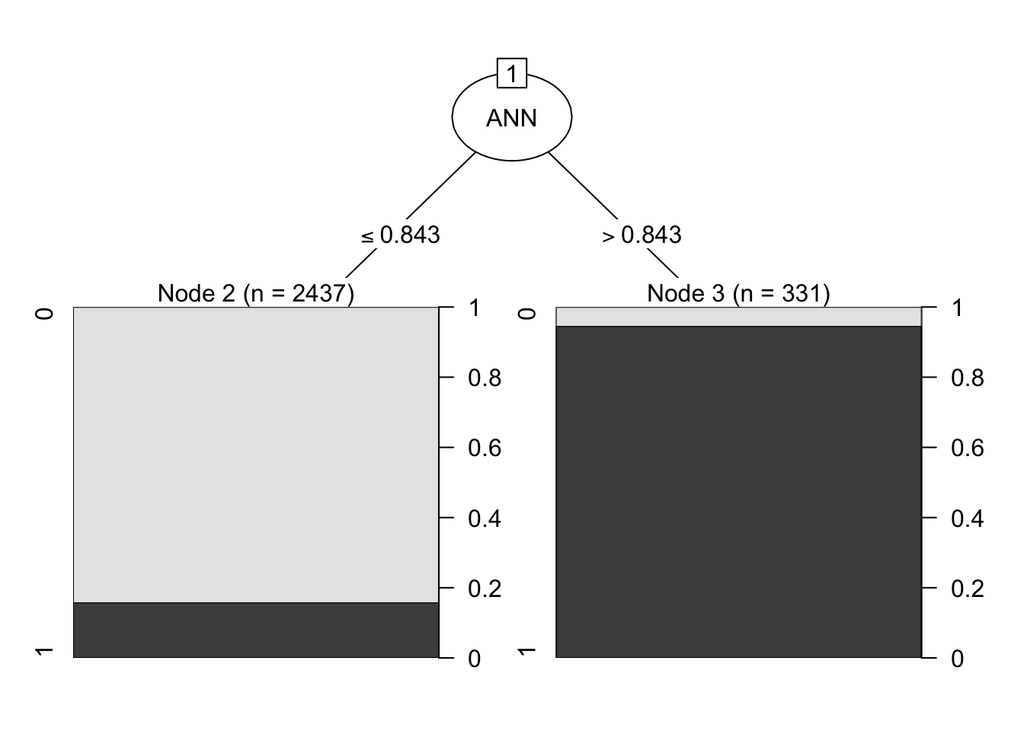

```r
combined_tune_tree <- C5.0(as.factor(combined_tune_train_labels) ~., data = combined_tune_train)

plot(combined_tune_tree)
```

```r
summary(combined_tune_tree)
```

```
##
## Call:
## C5.0.formula(formula = as.factor(combined_tune_train_labels) ~ ., data
##  = combined_tune_train)
##
##
## C5.0 [Release 2.07 GPL Edition]      Mon Apr 17 22:34:04 2023
## -------------------------------
##
## Class specified by attribute `outcome'
##
## Read 2768 cases (6 attributes) from undefined.data
##
## Decision tree:
##
## ANN <= 0.8434474: 0 (2438/385)
## ANN > 0.8434474: 1 (330/17)
##
##
## Evaluation on training data (2768 cases):
##
##      Decision Tree
##    ----------------
##    Size      Errors
##
##       2  402(14.5%)   <<
##
##
##     (a)   (b)    <-classified as
##    ----  ----
##    2053    17    (a): class 0
##     385   313    (b): class 1
##
##
##  Attribute usage:
##
##  100.00% ANN
##
##
## Time: 0.0 secs
```

```r
combined_tune_pred <- predict(combined_tune_tree, combined_tune_test)

m<- confusionMatrix(as.factor(combined_tune_pred), as.factor(combined_tune_test_labels), positive = "1")

kappa_combinedtunedDT<-l$overall["Kappa"]
print(kappa_combinedtunedDT)
```

```
##     Kappa
## 0.5224897
```

```r
print(m)
```

```
## Confusion Matrix and Statistics
##
##           Reference
## Prediction   0   1
##          0 877 185
##          1   4 119
##
##                Accuracy : 0.8405
##                  95% CI : (0.8184, 0.8609)
##     No Information Rate : 0.7435
##     P-Value [Acc > NIR] : 6.082e-16
##
##                   Kappa : 0.4806
##
##  Mcnemar's Test P-Value : < 2.2e-16
##
##             Sensitivity : 0.3914
##             Specificity : 0.9955
##          Pos Pred Value : 0.9675
##          Neg Pred Value : 0.8258
##              Prevalence : 0.2565
##          Detection Rate : 0.1004
##    Detection Prevalence : 0.1038
##       Balanced Accuracy : 0.6935
##
##        'Positive' Class : 1
##
```

The generated matrix shows that the Decision Tree with Combined Tuning successfully predicted 119 cars will be sold successfully, and that we should avoid buying 877 cars as they will not be sold. However, the prediction causes us to miss out on 185 cars, as they could have been sold, but they were not purchased. Furthermore, we take a loss on 4 cars, as we bought those cars and will not be able to sell them.

## Cost Matrix of the Combined-Tuned Model

```r
error_cost <- matrix(c(0, 1, 4, 0), nrow = 2)

#error_cost

error_tune_model <- C5.0(as.factor(combined_tune_train_labels) ~ ., data = combined_tune_train, costs = error_cost)
error_tune_pred <- predict(error_tune_model, combined_tune_test)
n<- confusionMatrix(as.factor(error_tune_pred), as.factor(combined_tune_test_labels), positive = "1")
kappa_comninedtunedCostMat<- m$overall["Kappa"]
print(kappa_comninedtunedCostMat)
```

```
##     Kappa
## 0.4806139
```

```r
print(n)
```

```
## Confusion Matrix and Statistics
##
##           Reference
## Prediction   0   1
##          0 540  77
##          1 341 227
##
##                Accuracy : 0.6473
##                  95% CI : (0.6193, 0.6745)
##     No Information Rate : 0.7435
##     P-Value [Acc > NIR] : 1
##
##                   Kappa : 0.28
##
##  Mcnemar's Test P-Value : <2e-16
##
##             Sensitivity : 0.7467
##             Specificity : 0.6129
##          Pos Pred Value : 0.3996
##          Neg Pred Value : 0.8752
##              Prevalence : 0.2565
##          Detection Rate : 0.1916
##    Detection Prevalence : 0.4793
##       Balanced Accuracy : 0.6798
##
##        'Positive' Class : 1
##
```

The generated matrix shows that the Cost Matrix of the Combined-Tuned Model successfully predicted 227 cars will be sold successfully, and that we should avoid buying 540 cars as they will not be sold. However, the prediction causes us to miss out on 77 cars, as they could have been sold, but they were not purchased. Furthermore, we take a loss on 341 cars, as we bought those cars and will not be able to sell them.

# Kappa Values and Accuracy Summary

```r
Kappa_Summary_Table<-data.frame(kappa_Regression=kappa_Regression,kappa_KNN=kappa_KNN,kappa_ANN=kappa_ANN, kappa_RandomForest=kappa_RandomForest, kappa_DecisionTree=kappa_DecisionTree, kappa_StackedModelDT=kappa_StackedModelDT, kappa_InitialCostMatrix=kappa_InitialCostMatrix, kappa_ImprovedDT=kappa_ImprovedDT,kappa_TunedRegression=kappa_TunedRegression,Kappa_TunedKNN=Kappa_TunedKNN, kappa_TunedRandomForest,kappa_TunedANN=kappa_TunedANN, kappa_combinedtunedDT=kappa_combinedtunedDT, kappa_comninedtunedCostMat=kappa_comninedtunedCostMat)

print(t(Kappa_Summary_Table))
```

```
##                                Kappa
## kappa_Regression           0.4571093
## kappa_KNN                  0.4193596
## kappa_ANN                  0.3684457
## kappa_RandomForest         0.5208313
## kappa_DecisionTree         0.5073360
## kappa_StackedModelDT       0.5113900
## kappa_InitialCostMatrix    0.2564952
## kappa_ImprovedDT           0.5224897
## kappa_TunedRegression      0.5224897
## Kappa_TunedKNN             0.4878640
## kappa_TunedRandomForest    0.5238761
## kappa_TunedANN             0.5153773
## kappa_combinedtunedDT      0.5224897
## kappa_comninedtunedCostMat 0.4806139
```